# ggplot-plot-title

Pawan

2022-12-09

When using ggplot2 we can set a title, subtitle, caption, and tag of the plot. There are two ways to add title, subtitle; (i) using ggtitle, (ii) using labs function.

# ggtitle

Let’s adding title, subtitle of the plot in ggplot2 using of ggtitle

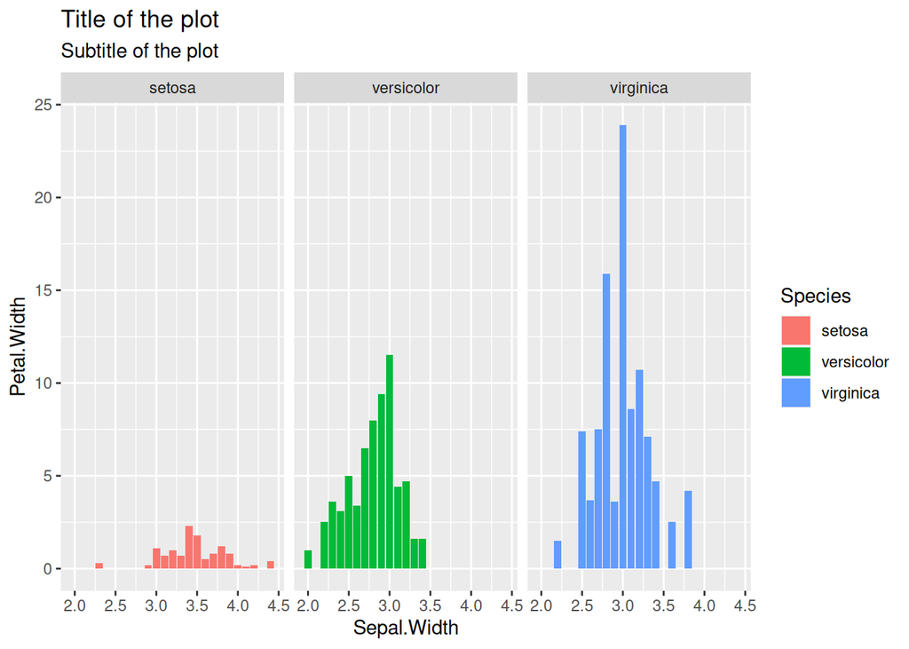

```r
library(ggplot2)

data<-iris

ggplot(data, aes(x = Sepal.Width, y = Petal.Width, fill = Species)) +
  geom_bar(stat = "identity") +
  facet_wrap(~Species) +
  ggtitle("Title of the plot",
          subtitle = "Subtitle of the plot")->p
p
```

## Option 2. Using labs

You can also use the labs function to add the title.

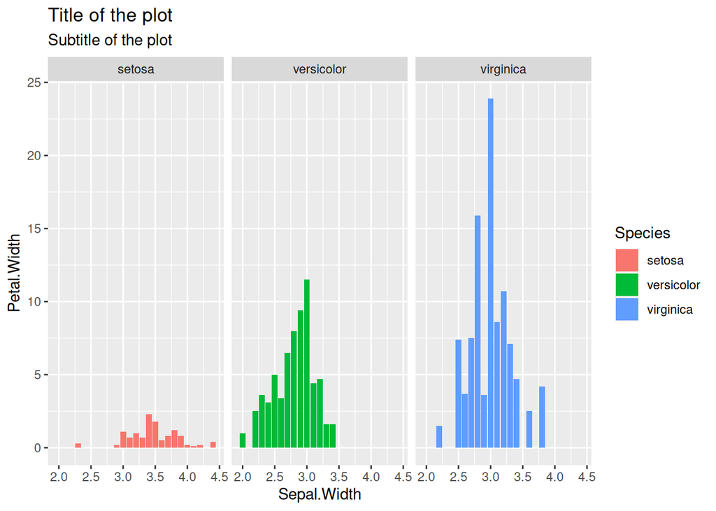

```r
# install.packages(ggplot2)
library(ggplot2)
data<-iris

ggplot(data, aes(x = Sepal.Width, y = Petal.Width, fill = Species)) +
  geom_bar(stat = "identity") +
  facet_wrap(~Species) +
  labs(title = "Title of the plot",
       subtitle = "Subtitle of the plot")->p
p
```

## Title position

The title position can be set respect to the whole plot instead of the panel with the plot.title.position component of the theme function. Default value is “panel”. This configuration also applies to the subtitle.

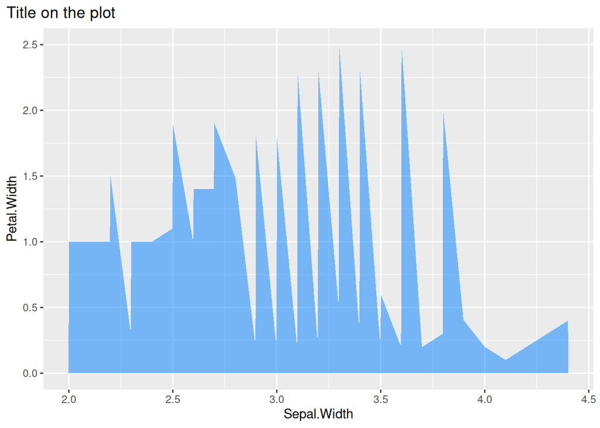

```r
# install.packages(ggplot2)
library(ggplot2)

ggplot(data, aes(x = Sepal.Width, y = Petal.Width)) +
  geom_area(fill = rgb(0, 0.5, 1, alpha = 0.5)) +
  labs(title = "Title on the plot") +
  theme(plot.title.position = "plot")
```

# Subtitle

You can add a subtitle the same way you added the title, but with the subtitle argument.

Add a subtitle in ggplot2

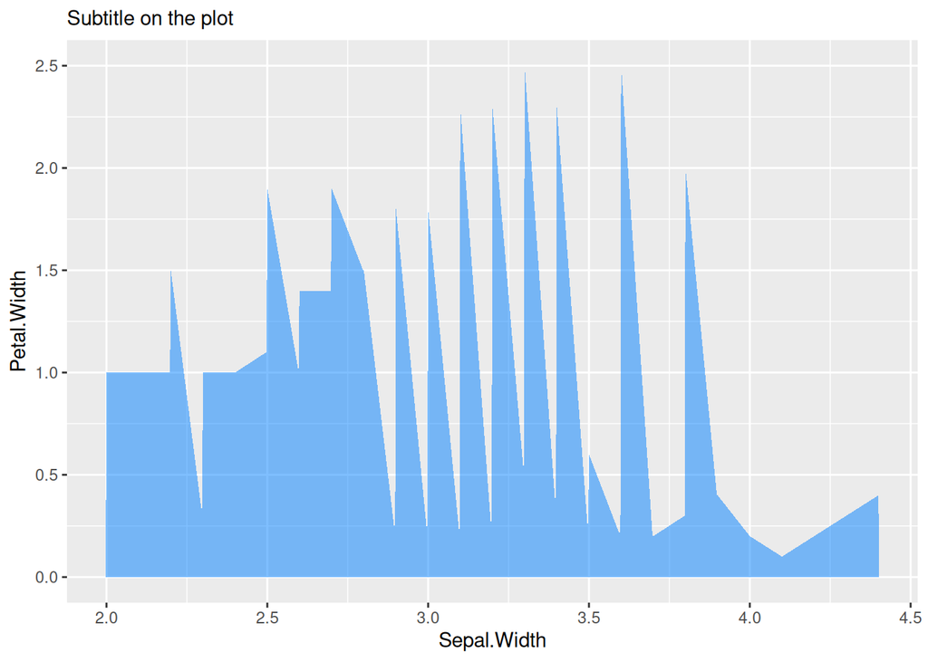

```r
# install.packages(ggplot2)
library(ggplot2)

ggplot(data, aes(x = Sepal.Width, y = Petal.Width)) +
  geom_area(fill = rgb(0, 0.5, 1, alpha = 0.5)) +
  labs(subtitle = "Subtitle on the plot")
```

## Option 2. Using labs

Subtitle in ggplot2 using labs

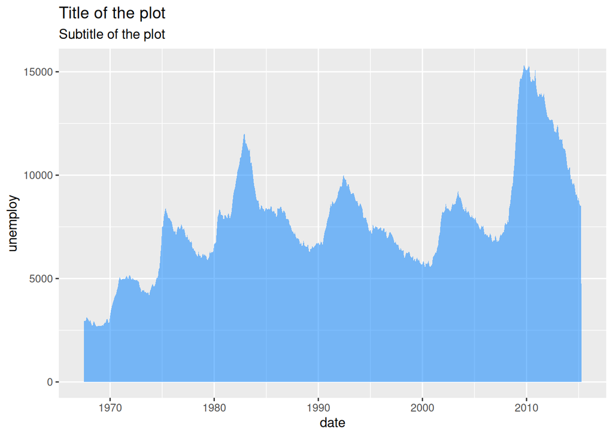

```r
# install.packages(ggplot2)
library(ggplot2)

ggplot(economics, aes(date, unemploy)) +
  geom_area(fill = rgb(0, 0.5, 1, alpha = 0.5)) +
  labs(title = "Title of the plot",
       subtitle = "Subtitle of the plot")
```

# Caption

A caption can be used to describe the figure. You can add it with the caption argument of the labs function.

Adding a caption in ggplot2

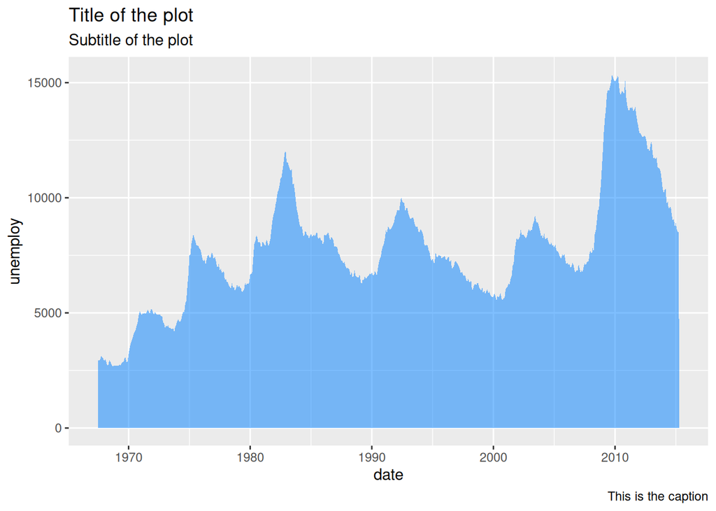

```r
# install.packages(ggplot2)
library(ggplot2)

ggplot(economics, aes(date, unemploy)) +
  geom_area(fill = rgb(0, 0.5, 1, alpha = 0.5)) +
  labs(title = "Title of the plot",
       subtitle = "Subtitle of the plot",
       caption = "This is the caption")
```

The plot.caption.position of the theme function allows aliging the caption to the panel (“panel”, default) or the whole plot (“plot”).

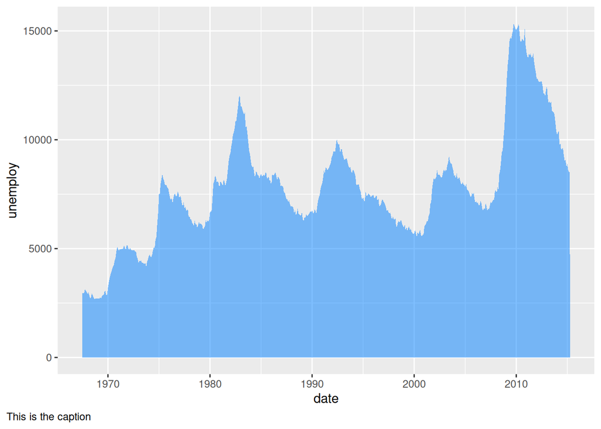

```r
# install.packages(ggplot2)
library(ggplot2)

ggplot(economics, aes(date, unemploy)) +
  geom_area(fill = rgb(0, 0.5, 1, alpha = 0.5)) +
  labs(caption = "This is the caption") +
  theme(plot.caption.position = "plot",
        plot.caption = element_text(hjust = 0))
```

Changing the caption position in ggplot2

Note that the default for the caption is right alignment, so you can set hjust = 0 to move the caption to the left of the whole plot.

# Tag

Adding a tag to the plot in ggplot2

Tags are useful to indicate the figure numbering. You can add it with the tag argument of the labs function.

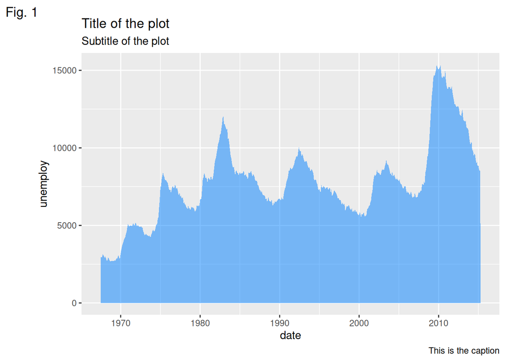

```r
# install.packages(ggplot2)
library(ggplot2)

ggplot(economics, aes(date, unemploy)) +
  geom_area(fill = rgb(0, 0.5, 1, alpha = 0.5)) +
  labs(title = "Title of the plot",
       subtitle = "Subtitle of the plot",
       caption = "This is the caption",
       tag = "Fig. 1")
```

## Tag position

Changing the tag position in ggplot2

The position of the tag can be set with the plot.tag.position component of the theme function. Possible values are “topleft” (default), “top”, “topright”, “left”, “right”, “bottomleft”, “bottom” or “bottomright”.

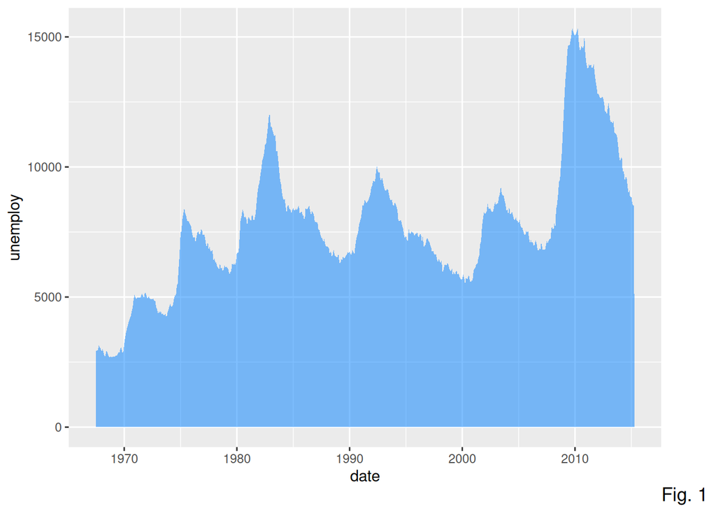

```r
# install.packages(ggplot2)
library(ggplot2)

ggplot(economics, aes(date, unemploy)) +
  geom_area(fill = rgb(0, 0.5, 1, alpha = 0.5)) +
  labs(tag = "Fig. 1") +
  theme(plot.tag.position = "bottomright")
```

# Further styles and adjustments

The titles, subtitles, captions and tags can be customized with the plot.title, plot.subtitle, plot.caption and plot.tag components of the theme function, making use of element_text. You can modify the color, the font family, the text size, the text face, the angle or the vertical and horizontal adjustment for each text as in the example below.

Styling the titles in ggplot2, such as modifying the color, size, face, family, lineheight and margins

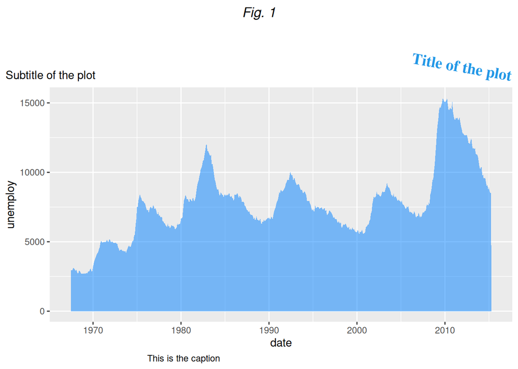

```r
# install.packages(ggplot2)
library(ggplot2)

ggplot(economics, aes(date, unemploy)) +
  geom_area(fill = rgb(0, 0.5, 1, alpha = 0.5)) +
  labs(title = "Title of the plot",
       subtitle = "Subtitle of the plot",
       caption = "This is the caption",
       tag = "Fig. 1") +
  theme(plot.title = element_text(family = "serif",              # Font family
                                  face = "bold",                 # Font face
                                  color = 4,                     # Font color
                                  size = 15,                     # Font size
                                  hjust = 1,                     # Horizontal adjustment
                                  vjust = 1,                     # Vertical adjustment
                                  angle = -10,                   # Font angle
                                  lineheight = 1,                # Line spacing
                                  margin = margin(20, 0, 0, 0)), # Margins (t, r, b, l)
        plot.subtitle = element_text(hjust = 0),                 # Subtitle customization
        plot.caption = element_text(hjust = 0.25),               # Caption customization
        plot.tag = element_text(face = "italic"),                # Tag customization
        plot.title.position = "plot",                            # Title and subtitle position ("plot" or "panel")
        plot.caption.position = "panel",                         # Caption position ("plot" or "panel")
        plot.tag.position = "top")                               # Tag position
```